# Membership Woes

Pranay Kothari

July 9, 2019

### CASE:

A certain premium club boasts a large customer membership. The members pay an annual membership fee in return for using the exclusive facilities offered by this club. The fees are customized for every member’s personal package.In the last few years, however, the club has been facing an issue with a lot of members cancelling their memberships. The club management plans to address this issue by proactively addressing customer grievances. They, however, do not have enough bandwidth to reach out to the entire customer base individually and are looking to see whether a statistical approach can help them identify customers at risk. Can you help them ?

### SOLUTION:

We will be building a machine learning model to predict customers at risk. Looking at the data we have found the following: 1. Annual fees has very high variation for different customers. 2. Membership term years are generally long. 3. There are 2 types of packages and 5 modes of payments. Single premium customers have never cancelled their membership. 4. There a are more MALES who are members than FEMALES. Also, most members are married.

#### Assumptions:

1. Where marital status is missing, their status is ‘other’ than the given 4.
2. Where gender is missing, their status is ‘other’ than M or F.
3. Member annual income and Annual fees are independent of each other. The strange relation between the two suggests omitted variables.
4. Where the occupation code is NA, they belong to the 7th occupation (‘others’).

**Let’s start…**

### IMPORTING LIBRARIES

First, we will import all the libraries that we will need on our way.

```r
library(xlsx)         #Import Excel file
library(naniar)       #to visualize missing data
library(lubridate)    #for dates
library(ggplot2)      #Visualization
library(ggthemes)     #Visualization
library(scales)       #Visualization
library(caTools)      #Train Test Split
library(caret)        #Classification And REgression Training
library(rpart)        #Decision Trees
library(rpart.plot)   #Visualize decision tree
library(randomForest) #Random Forest
```

### Exploratory Data Analysis, Feature Engineering and Feature Selection

Import the Data into R.

```r
#Importing data into Dataset.
#defining data types.
df = read.xlsx('C:/Users/StarTrek/Desktop/DS/Membership woe/Assignment- Membership woes.xlsx', sheetName = 'Data', colClasses = c("character", "numeric", "numeric", "character", "character", "numeric", "character", "character", "numeric", "numeric", "character", "character", "character", "character", "character"))
```

Dimension of the dataset:

```r
dim(df)
```

```
## [1] 10362    15
```

Checking null values:

```r
any(df == '')
```

```
## [1] TRUE
```

```r
any(df == 'NA')
```

```
## [1] TRUE
```

Replacing string null values with R - NA :

```r
df[df == ''] = NA
df[df == 'NA'] = NA
```

Preview of the dataset:

```r
head(df)
```

```
##   MEMBERSHIP_NUMBER MEMBERSHIP_TERM_YEARS ANNUAL_FEES
## 1            A00001                    29      113125
## 2            A00002                    38      112220
## 3            A00003                    12      100000
## 4            A00004                    12      100000
## 5            A00005                    46      100000
## 6            A00006                    12      110000
##   MEMBER_MARITAL_STATUS MEMBER_GENDER MEMBER_ANNUAL_INCOME
## 1                     M             M             25200000
## 2                     M             M             10339200
## 3                     M             M             14400000
## 4                     M             M              9000000
## 5                     M             M              4800000
## 6                  <NA>          <NA>                   NA
##   MEMBER_OCCUPATION_CD MEMBERSHIP_PACKAGE MEMBER_AGE_AT_ISSUE
```

[output cut: 20 more lines]

Summary - check statistics of the features:

```r
summary(df)
```

```
##  MEMBERSHIP_NUMBER MEMBERSHIP_TERM_YEARS  ANNUAL_FEES
##  A00001 :    1     Min.   :  9.00        Min.   :       0
##  A00002 :    1     1st Qu.: 12.00        1st Qu.:  100000
##  A00003 :    1     Median : 19.00        Median :  118209
##  A00004 :    1     Mean   : 29.39        Mean   :  178812
##  A00005 :    1     3rd Qu.: 37.00        3rd Qu.:  190000
##  A00006 :    1     Max.   :102.00        Max.   :10100000
##  (Other):10356
##  MEMBER_MARITAL_STATUS MEMBER_GENDER MEMBER_ANNUAL_INCOME
##  D   :  45             F   :2421     Min.   :     9996
##  M   :6430             M   :7330     1st Qu.:   399996
##  S   :1144             NA's: 611     Median :   549996
##  W   : 146                           Mean   :  1451100
##  NA's:2597                           3rd Qu.:   999996
##                                      Max.   :999999996
##                                      NA's   :1754
##  MEMBER_OCCUPATION_CD MEMBERSHIP_PACKAGE MEMBER_AGE_AT_ISSUE
##  1      :7281         TYPE-A:3553        Min.   : 0.0
##  2      :1778         TYPE-B:6809        1st Qu.:37.0
##  6      : 728                            Median :46.0
##  5      : 324                            Mean   :46.8
##  4      : 207                            3rd Qu.:57.0
##  (Other):   1                            Max.   :92.0
##  NA's   :  43
##  ADDITIONAL_MEMBERS         PAYMENT_MODE    AGENT_CODE   MEMBERSHIP_STATUS
##  Min.   :0.000      ANNUAL        :6589   343344 : 612   CANCELLED:3143
##  1st Qu.:0.000      MONTHLY       :1881   348355 : 118   INFORCE  :7219
##  Median :1.000      QUARTERLY     : 390   343477 :  95
##  Mean   :1.412      SEMI-ANNUAL   :1493   309877 :  63
##  3rd Qu.:2.000      SINGLE-PREMIUM:   9   343466 :  63
##  Max.   :3.000                            1347266:  56
##                                           (Other):9355
##  START_DATE..YYYYMMDD. END_DATE...YYYYMMDD.
##  20130331: 242         20130527: 116
##  20100831: 212         20111027:  66
##  20120330: 203         20110527:  56
##  20100331: 196         20120527:  36
##  20130930: 105         20110926:  33
##  20110331:  95         (Other) :2836
##  (Other) :9309         NA's    :7219
```

We have 5 numeric features. Some of these can be bucketted. There are 2 Date columns, but they need transformation. Three columns - “MEMBERSHIP_NUMBER”, “AGENT_CODE” and “END_DATE (YYYYMMDD)” which will not be contributing to prediction. Remaining features are categorical in nature.

Structure - More about the values in each feature:

```r
str(df)
```

```
## 'data.frame':    10362 obs. of  15 variables:
##  $ MEMBERSHIP_NUMBER    : Factor w/ 10362 levels "A00001","A00002",..: 1 2 3 4 5 6 7 8 9 10 ...
##  $ MEMBERSHIP_TERM_YEARS: num  29 38 12 12 46 12 36 12 35 33 ...
##  $ ANNUAL_FEES          : num  113125 112220 100000 100000 100000 ...
##  $ MEMBER_MARITAL_STATUS: Factor w/ 4 levels "D","M","S","W": 2 2 2 2 2 NA 2 2 NA 2 ...
##  $ MEMBER_GENDER        : Factor w/ 2 levels "F","M": 2 2 2 2 2 NA 2 2 NA 2 ...
##  $ MEMBER_ANNUAL_INCOME : num  25200000 10339200 14400000 9000000 4800000 ...
##  $ MEMBER_OCCUPATION_CD : Factor w/ 7 levels "1","2","3","4",..: 1 1 1 1 1 1 1 1 1 1 ...
##  $ MEMBERSHIP_PACKAGE   : Factor w/ 2 levels "TYPE-A","TYPE-B": 2 2 2 2 2 2 2 2 2 2 ...
##  $ MEMBER_AGE_AT_ISSUE  : num  45 36 42 39 27 48 39 28 35 42 ...
##  $ ADDITIONAL_MEMBERS   : num  2 3 1 2 2 3 2 1 2 2 ...
##  $ PAYMENT_MODE         : Factor w/ 5 levels "ANNUAL","MONTHLY",..: 1 3 1 1 3 1 1 3 2 4 ...
##  $ AGENT_CODE           : Factor w/ 4317 levels "..","1001155",..: 2779 2185 3729 1992 3454 2905 2602 1122 2712 237 ...
##  $ MEMBERSHIP_STATUS    : Factor w/ 2 levels "CANCELLED","INFORCE": 2 2 2 2 2 2 2 1 2 2 ...
##  $ START_DATE..YYYYMMDD.: Factor w/ 1300 levels "20060914","20061102",..: 1 2 4 3 5 6 7 8 9 11 ...
##  $ END_DATE...YYYYMMDD. : Factor w/ 1062 levels "","20070827",..: NA NA NA NA NA NA NA 149 NA NA ...
```

Features “MEMBERSHIP_NUMBER”, “AGENT_CODE” and “END_DATE (YYYYMMDD)” will not be contributing to the prediction. Therefore, removing these features .

```r
cols = c("MEMBERSHIP_NUMBER", "AGENT_CODE" , "END_DATE...YYYYMMDD.")
df = df[!(names(df) %in% cols)]
```

Visualizing missing columns:

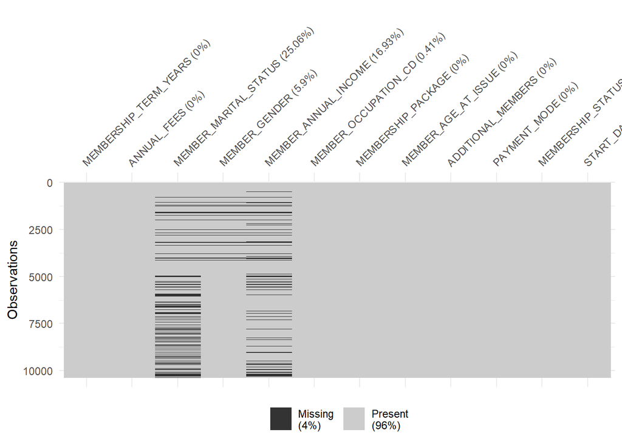

```r
vis_miss(df)
```

Count of missing values in features with missing values:

```r
colSums(sapply(df,is.na))[colSums(sapply(df,is.na))>0]
```

```
## MEMBER_MARITAL_STATUS         MEMBER_GENDER  MEMBER_ANNUAL_INCOME
##                  2597                   611                  1754
##  MEMBER_OCCUPATION_CD
##                    43
```

Missing map did not shopw us about the NA’s present under “MEMBER_OCCUPATION_CD”. But the count above tells us that there are few NA’s in “MEMBER_OCCUPATION_CD” as well.

Replacing NA values in features, feature engineering date and converting categorical features in to factors:

```r
df$MEMBER_MARITAL_STATUS = as.character(df$MEMBER_MARITAL_STATUS)
df$MEMBER_MARITAL_STATUS[is.na(df$MEMBER_MARITAL_STATUS)] = 'O'
df$MEMBER_MARITAL_STATUS = factor(df$MEMBER_MARITAL_STATUS)

df$MEMBER_GENDER = as.character(df$MEMBER_GENDER)
df$MEMBER_GENDER[is.na(df$MEMBER_GENDER)] = 'O'
df$MEMBER_GENDER = factor(df$MEMBER_GENDER)


#Replacing NA's in "MEMBER_OCCUPATION_CD"" with a category
df$MEMBER_OCCUPATION_CD = as.character(df$MEMBER_OCCUPATION_CD)
df$MEMBER_OCCUPATION_CD[is.na(df$MEMBER_OCCUPATION_CD)] = '7'
df$MEMBER_OCCUPATION_CD = factor(df$MEMBER_OCCUPATION_CD)


#Converting the date columns in to "date" datatype and then creating 2 columns - Year and Month from this. We therefore, created categorical columns which will be better for prediction.
df$START_DATE..YYYYMMDD. = as.Date(df$START_DATE..YYYYMMDD.,"%Y%m%d")
df$START_YR = factor(year(df$START_DATE..YYYYMMDD.))
df$START_MONTH = factor(month(df$START_DATE..YYYYMMDD.))
df$START_DATE..YYYYMMDD. = NULL

#NA in MEMBER_ANNUAL_INCOME
df$MEMBER_ANNUAL_INCOME[is.na(df$MEMBER_ANNUAL_INCOME)] = median(df$MEMBER_ANNUAL_INCOME, na.rm = TRUE)


df$PAYMENT_MODE = factor(df$PAYMENT_MODE)
df$MEMBERSHIP_PACKAGE = factor(df$MEMBERSHIP_PACKAGE)
df$MEMBERSHIP_STATUS  = factor(df$MEMBERSHIP_STATUS )
```

#### Univariate Analysis

**Numeric Features**

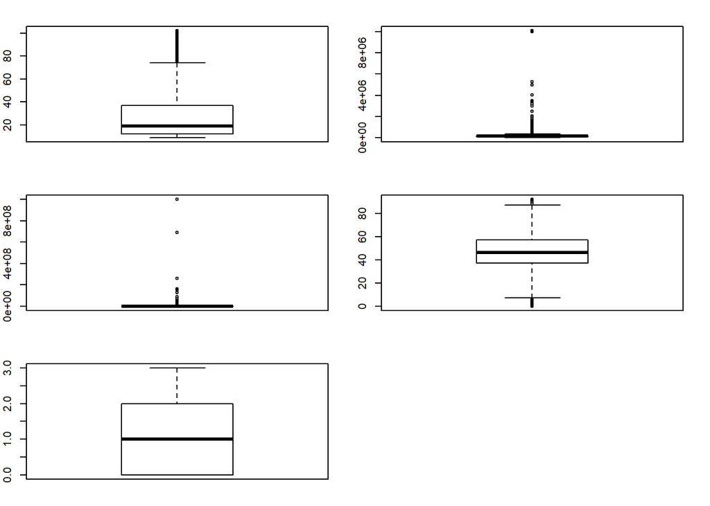

```r
par(mfrow=c(3,2))
par(mar=c(2,2,2,2))
boxplot(df$MEMBERSHIP_TERM_YEARS)
boxplot(df$ANNUAL_FEES)
boxplot(df$MEMBER_ANNUAL_INCOME)
boxplot(df$MEMBER_AGE_AT_ISSUE)
boxplot(df$ADDITIONAL_MEMBERS)
```

We observed that “ANNUAL_FEES” and " “MEMBER_ANNUAL_INCOME” statistically has outliers. However, Income is a factor which is known to have great variation. ANNUAL_FEES is also varying due to the fact mentioned in the case “The fees are customized for every member’s personal package”. Moreover, I had tried treating the outlier it did not give better result. **Therefore, we will not treat the outliers.**

**Categorical Features**

```r
table(df$MEMBER_MARITAL_STATUS)
```

```
##
##    D    M    O    S    W
##   45 6430 2597 1144  146
```

```r
table(df$MEMBER_GENDER)
```

```
##
##    F    M    O
## 2421 7330  611
```

```r
table(df$MEMBER_OCCUPATION_CD)
```

```
##
##    1    2    3    4    5    6    7
## 7281 1778    1  207  324  728   43
```

```r
table(df$MEMBERSHIP_PACKAGE)
```

```
##
## TYPE-A TYPE-B
##   3553   6809
```

```r
table(df$PAYMENT_MODE)
```

```
##
##         ANNUAL        MONTHLY      QUARTERLY    SEMI-ANNUAL SINGLE-PREMIUM
##           6589           1881            390           1493              9
```

```r
table(df$MEMBERSHIP_STATUS)
```

```
##
## CANCELLED   INFORCE
##      3143      7219
```

```r
table(df$START_YR)
```

```
##
## 2006 2007 2008 2009 2010 2011 2012 2013
##    2  126 1022 1449 2590 1060 1595 2518
```

```r
table(df$START_MONTH)
```

```
##
##    1    2    3    4    5    6    7    8    9   10   11   12
##  837  997 2150  471  512  631  731 1015  747  683  715  873
```

Some features needs missing values treated.

Bucketting “MEMBERSHIP_TERM_YEARS” into 4 categories.

```r
df$MEMBERSHIP_TERM_YEARS[df$MEMBERSHIP_TERM_YEARS < 25] = "<25"
df$MEMBERSHIP_TERM_YEARS[df$MEMBERSHIP_TERM_YEARS >= 25 & df$MEMBERSHIP_TERM_YEARS < 50] = "25-49"
df$MEMBERSHIP_TERM_YEARS[df$MEMBERSHIP_TERM_YEARS >= 50 & df$MEMBERSHIP_TERM_YEARS < 75] = "50-74"
df$MEMBERSHIP_TERM_YEARS[df$MEMBERSHIP_TERM_YEARS >= 75] = "75+"
#following 3 will also be part of "75+"
df$MEMBERSHIP_TERM_YEARS[df$MEMBERSHIP_TERM_YEARS == 100] = "75+"
df$MEMBERSHIP_TERM_YEARS[df$MEMBERSHIP_TERM_YEARS == 101] = "75+"
df$MEMBERSHIP_TERM_YEARS[df$MEMBERSHIP_TERM_YEARS == 102] = "75+"
df$MEMBERSHIP_TERM_YEARS = factor(df$MEMBERSHIP_TERM_YEARS)
```

Bucketting “MEMBER_AGE_AT_ISSUE” into 4 categories.

```r
df$MEMBER_AGE_AT_ISSUE[df$MEMBER_AGE_AT_ISSUE < 25] = "<25"
df$MEMBER_AGE_AT_ISSUE[df$MEMBER_AGE_AT_ISSUE >= 25 & df$MEMBER_AGE_AT_ISSUE < 50] = "25-49"
df$MEMBER_AGE_AT_ISSUE[df$MEMBER_AGE_AT_ISSUE >= 50 & df$MEMBER_AGE_AT_ISSUE < 75] = "50-74"
df$MEMBER_AGE_AT_ISSUE[df$MEMBER_AGE_AT_ISSUE >= 75] = "75+"
df$MEMBER_AGE_AT_ISSUE = factor(df$MEMBER_AGE_AT_ISSUE)
```

#### Bivariate Analysis

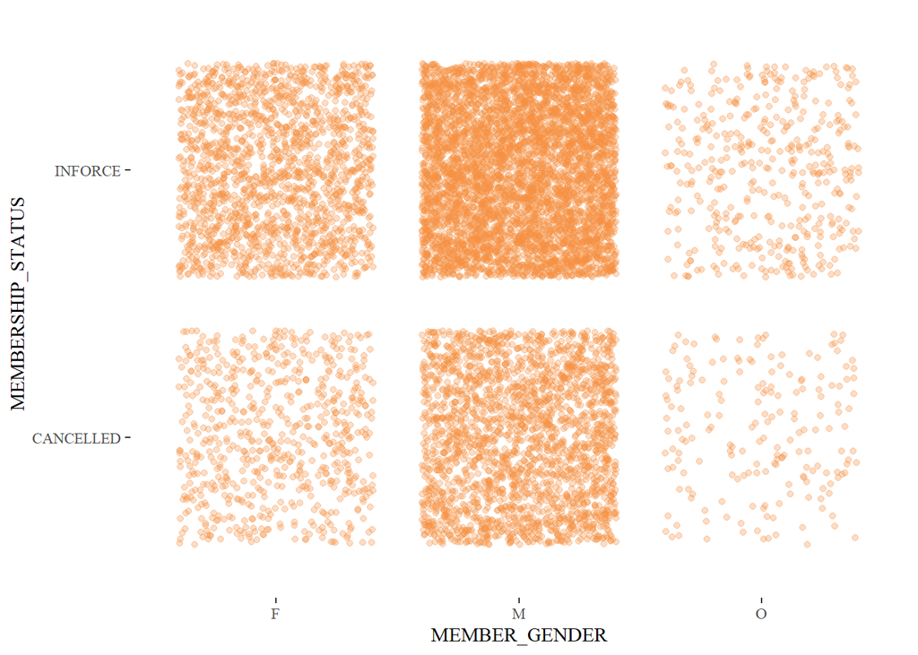

```r
par(mfrow=c(1,1))
ggplot(df, aes(MEMBER_GENDER,MEMBERSHIP_STATUS))+ geom_jitter(color =  '#f59042', alpha = 0.3) + theme_tufte()
```

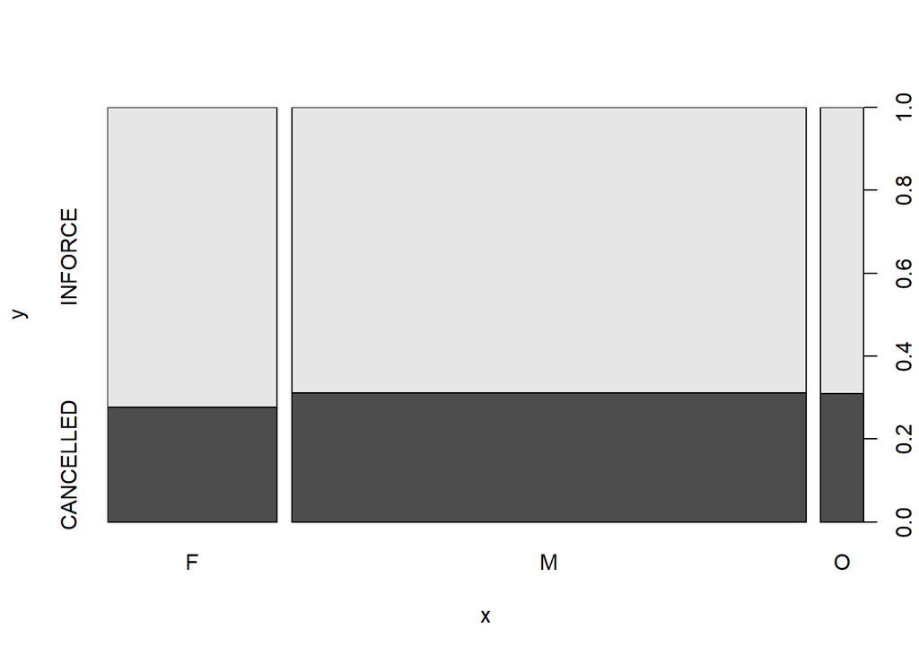

```r
plot(df$MEMBER_GENDER,df$MEMBERSHIP_STATUS)
```

Male, Female and ‘O’ seems to be proportionally contributing to cancellation. There are more males than Females.

Visualizing categorical predictors against the Target.

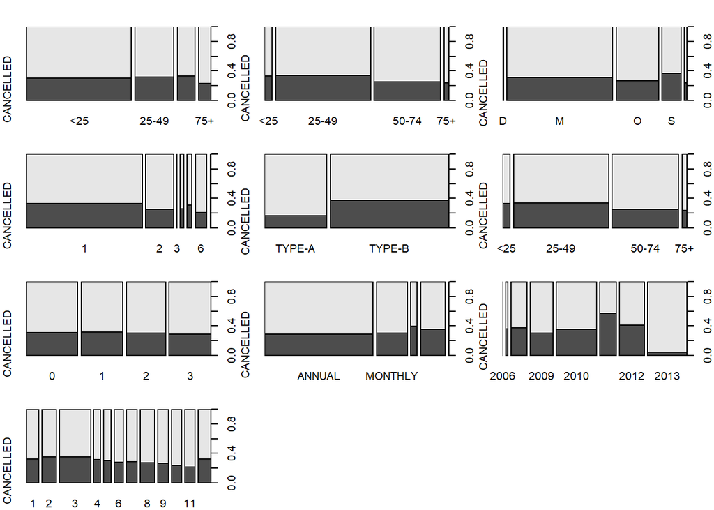

```r
par(mfrow=c(4,3)) #subplots - 4 rows, 3 columns
par(mar=c(2,2,2,2)) #Margins
plot(df$MEMBERSHIP_TERM_YEARS,df$MEMBERSHIP_STATUS)
plot(df$MEMBER_AGE_AT_ISSUE,df$MEMBERSHIP_STATUS)
plot(df$MEMBER_MARITAL_STATUS,df$MEMBERSHIP_STATUS)
plot(df$MEMBER_OCCUPATION_CD,df$MEMBERSHIP_STATUS)
plot(df$MEMBERSHIP_PACKAGE,df$MEMBERSHIP_STATUS)
plot(df$MEMBER_AGE_AT_ISSUE,df$MEMBERSHIP_STATUS)
plot(factor(df$ADDITIONAL_MEMBERS),df$MEMBERSHIP_STATUS)
plot(df$PAYMENT_MODE,df$MEMBERSHIP_STATUS)
plot(df$START_YR,df$MEMBERSHIP_STATUS)
plot(df$START_MONTH,df$MEMBERSHIP_STATUS)
```

Visualizing Numerical predictors against the Target.

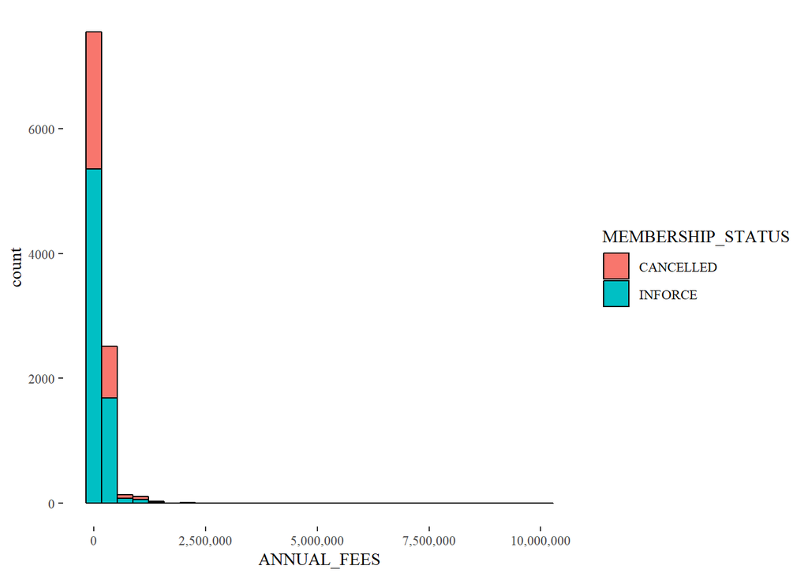

```r
par(mfrow=c(1,1))
ggplot(df, aes(ANNUAL_FEES)) + geom_histogram(color = 'Black',  aes(fill =MEMBERSHIP_STATUS)) + theme_tufte() + scale_x_continuous(labels = comma)
```

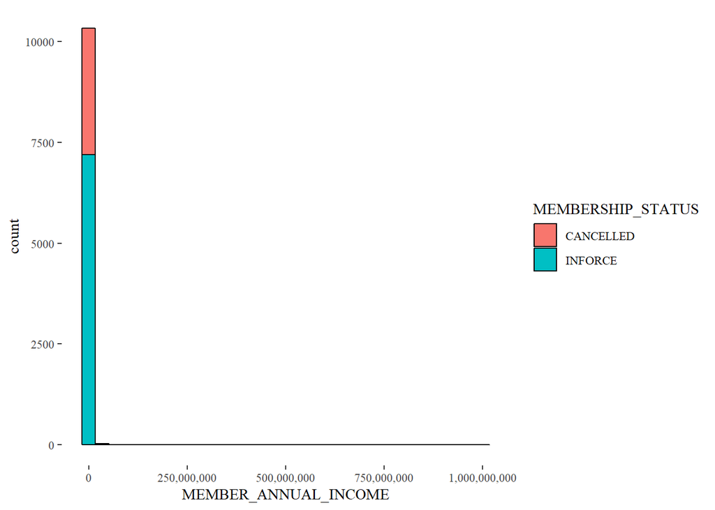

```r
ggplot(df, aes(MEMBER_ANNUAL_INCOME)) + geom_histogram(color = 'Black',  aes(fill =MEMBERSHIP_STATUS)) + theme_tufte() + scale_x_continuous(labels = comma)
```

Again, ANNUAL_FEES isn’t suggesting that it could a strong reason for “CANCELLATION”.

**From our exploratory data analysis, we found that there are 3 features that would not contribute to prediction so we removed those. There is no need for further FEATURE SELECTION as from our observation above suggests that remaining features are each contributing to predictions.**

### Model Building

Our primary task is to assist the club management in identifying members who could be at risk of cancelling membership. Apart, from recognizing potential threat we also need to inform the club about the areas that they should work on to retain the customer. Therefore, interpretability of the model is important. Keeping this thought in mind, we will evaluate three models that have good interpretibility: 1. Logistic Regression 2. Decision Trees. 3. Random Forest.

There are other ensemble techniques such as AdaBoos to Gradient Boosting which might give better prediction but we loose interpretibility.

#### Training and Testing Model

Divide Data into Train and Test

```r
sample = sample.split(df$ANNUAL_FEES, 0.8)
train = subset(df, sample == TRUE)
test = subset(df, sample == FALSE)
```

#### Logistic Regression

**Building Model**

```r
set.seed(50)
logistic_model <- train(form = MEMBERSHIP_STATUS ~ ., data=train, method="glm", metric="Accuracy", trControl=trainControl(method = "cv", number = 10))
#Model Accuracy and more details:
logistic_model
```

```
## Generalized Linear Model
##
## 8904 samples
##   12 predictor
##    2 classes: 'CANCELLED', 'INFORCE'
##
## No pre-processing
## Resampling: Cross-Validated (10 fold)
## Summary of sample sizes: 8013, 8014, 8014, 8013, 8014, 8014, ...
## Resampling results:
##
##   Accuracy   Kappa
##   0.7243955  0.2154381
```

Training Accuracy after 10-Fold Cross Validation = 0.72.

AIC and significant features:

```r
summary(logistic_model)
```

```
##
## Call:
## NULL
##
## Deviance Residuals:
##     Min       1Q   Median       3Q      Max
## -3.5498  -1.0881   0.3438   0.9112   2.0644
##
## Coefficients:
##                                Estimate Std. Error z value Pr(>|z|)
## (Intercept)                   1.476e+01  3.758e+02   0.039 0.968669
## `MEMBERSHIP_TERM_YEARS25-49` -4.324e-02  6.859e-02  -0.630 0.528393
## `MEMBERSHIP_TERM_YEARS50-74` -1.908e-02  9.055e-02  -0.211 0.833142
## `MEMBERSHIP_TERM_YEARS75+`    5.221e-01  1.419e-01   3.679 0.000234 ***
## ANNUAL_FEES                  -2.845e-07  9.308e-08  -3.056 0.002242 **
## MEMBER_MARITAL_STATUSM       -1.041e+00  5.140e-01  -2.025 0.042864 *
## MEMBER_MARITAL_STATUSO       -1.361e+00  5.177e-01  -2.630 0.008551 **
## MEMBER_MARITAL_STATUSS       -1.020e+00  5.163e-01  -1.975 0.048279 *
## MEMBER_MARITAL_STATUSW       -6.539e-01  5.549e-01  -1.178 0.238681
## MEMBER_GENDERM               -7.084e-02  6.524e-02  -1.086 0.277498
## MEMBER_GENDERO                5.079e-01  1.459e-01   3.480 0.000501 ***
## MEMBER_ANNUAL_INCOME          3.875e-08  1.466e-08   2.643 0.008223 **
## MEMBER_OCCUPATION_CD2        -3.432e-01  9.237e-02  -3.716 0.000203 ***
## MEMBER_OCCUPATION_CD3        -1.419e+01  5.354e+02  -0.027 0.978858
## MEMBER_OCCUPATION_CD4         2.305e-01  1.927e-01   1.196 0.231637
## MEMBER_OCCUPATION_CD5         7.658e-02  1.394e-01   0.549 0.582663
## MEMBER_OCCUPATION_CD6         4.198e-02  1.243e-01   0.338 0.735665
## MEMBER_OCCUPATION_CD7         5.413e-02  4.368e-01   0.124 0.901380
## `MEMBERSHIP_PACKAGETYPE-B`   -6.104e-01  9.229e-02  -6.614 3.74e-11 ***
## `MEMBER_AGE_AT_ISSUE25-49`   -1.700e-01  1.380e-01  -1.232 0.217772
## `MEMBER_AGE_AT_ISSUE50-74`    8.793e-02  1.462e-01   0.601 0.547579
## `MEMBER_AGE_AT_ISSUE75+`      1.102e-01  2.317e-01   0.476 0.634286
## ADDITIONAL_MEMBERS            8.617e-02  3.153e-02   2.733 0.006271 **
## PAYMENT_MODEMONTHLY          -3.772e-01  7.139e-02  -5.284 1.27e-07 ***
## PAYMENT_MODEQUARTERLY        -7.171e-01  1.274e-01  -5.628 1.82e-08 ***
## `PAYMENT_MODESEMI-ANNUAL`    -3.362e-01  7.228e-02  -4.651 3.30e-06 ***
## `PAYMENT_MODESINGLE-PREMIUM`  1.336e+01  1.856e+02   0.072 0.942642
## START_YR2007                 -1.264e+01  3.758e+02  -0.034 0.973174
## START_YR2008                 -1.247e+01  3.758e+02  -0.033 0.973519
## START_YR2009                 -1.224e+01  3.758e+02  -0.033 0.974022
```

[output cut: 10 more lines]

```
## START_MONTH8                  1.972e-01  1.222e-01   1.614 0.106609
## START_MONTH9                  1.145e-02  1.351e-01   0.085 0.932434
## START_MONTH10                 2.292e-01  1.397e-01   1.641 0.100869
## START_MONTH11                 5.322e-01  1.405e-01   3.788 0.000152 ***
## START_MONTH12                 2.748e-01  1.228e-01   2.237 0.025272 *
## ---
## Signif. codes:  0 '***' 0.001 '**' 0.01 '*' 0.05 '.' 0.1 ' ' 1
##
## (Dispersion parameter for binomial family taken to be 1)
##
##     Null deviance: 10864.3  on 8903  degrees of freedom
## Residual deviance:  9176.9  on 8859  degrees of freedom
## AIC: 9266.9
##
## Number of Fisher Scoring iterations: 12
```

**Testing Model**

```r
#Predict
pred = predict(logistic_model,test)

#Confusion Matrix
cm = table(test$MEMBERSHIP_STATUS,pred)
cm
```

```
##            pred
##             CANCELLED INFORCE
##   CANCELLED       128     352
##   INFORCE          77     901
```

```r
#Calculate metrics
Accuracy = (cm[1] + cm[4])/sum(cm)
Precision = cm[4]/(cm[3] + cm[4])
Recall = cm[4]/(cm[2] + cm[4])
lg_stats = c('LG', round(Accuracy,2),round(Precision,2),round(Recall,2))  #Storing

#Print
cat("Accuracy is ", lg_stats[2])
```

```
## Accuracy is  0.71
```

```r
cat("Precision is ", lg_stats[3])
```

```
## Precision is  0.72
```

```r
cat("Recall is ", lg_stats[4])
```

```
## Recall is  0.92
```

Payment Mode - monthly, wuarterly and semi-annualy are significant. As inferred above, SINGLE-PREMIUM is not significant. Package type-B needs attention. members with occupation code = 2 are significant predictor. Membership term year beyond 75+ years and Annual fees are significant too.

#### Decision Trees

**Building Model**

```r
set.seed(50)
tree_model <- train(form = MEMBERSHIP_STATUS ~ ., data=train, method="rpart", parms = list(split ="information"),metric="Accuracy", trControl=trainControl(method = "cv", number = 10))
#Model Accuracy and more details:
tree_model
```

```
## CART
##
## 8904 samples
##   12 predictor
##    2 classes: 'CANCELLED', 'INFORCE'
##
## No pre-processing
## Resampling: Cross-Validated (10 fold)
## Summary of sample sizes: 8013, 8014, 8014, 8013, 8014, 8014, ...
## Resampling results across tuning parameters:
##
##   cp           Accuracy   Kappa
##   0.006571536  0.7181051  0.17553607
##   0.013894104  0.7132756  0.15530939
##   0.020090124  0.7042886  0.07238493
##
## Accuracy was used to select the optimal model using the largest value.
## The final value used for the model was cp = 0.006571536.
```

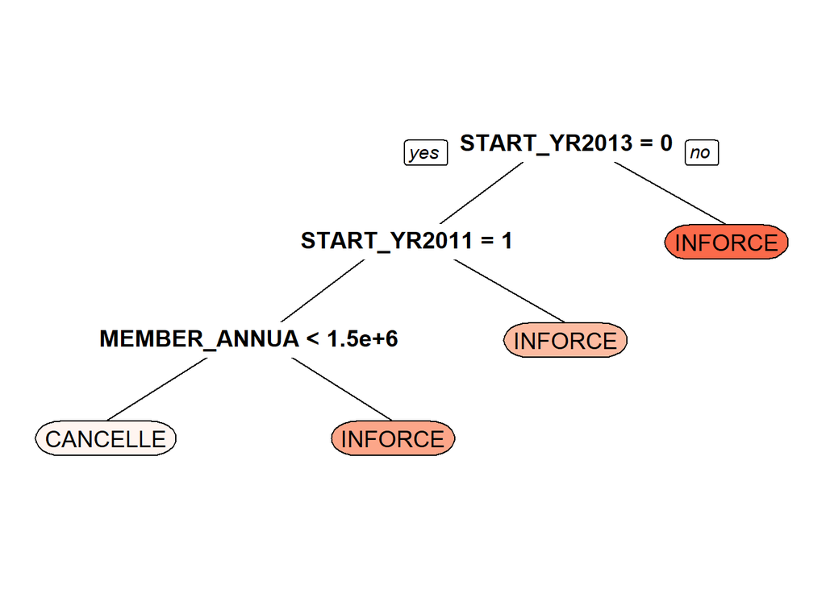

```r
#plot
prp(tree_model$finalModel, box.palette = "Reds", tweak = 1.2)
```

**Testing Model**

```r
#Predict
pred = predict(tree_model,test)

#Confusion Matrix
cm = table(test$MEMBERSHIP_STATUS,pred)

#Calculate metrics
Accuracy = (cm[1] + cm[4])/sum(cm)
Precision = cm[4]/(cm[3] + cm[4])
Recall = cm[4]/(cm[2] + cm[4])
tree_stats = c('TREE', round(Accuracy,2),round(Precision,2),round(Recall,2))  #Storing

#Print
cat("Accuracy is ", tree_stats[2])
```

```
## Accuracy is  0.7
```

```r
cat("Precision is ", tree_stats[3])
```

```
## Precision is  0.7
```

```r
cat("Recall is ", tree_stats[4])
```

```
## Recall is  0.96
```

#### Random Forest

**Building Model**

```r
rf_model <- randomForest(form = MEMBERSHIP_STATUS ~ ., data=train, ntree=500)
#Significant predictors
importance(rf_model)
```

```
##                       MeanDecreaseGini
## MEMBERSHIP_TERM_YEARS        151.48309
## ANNUAL_FEES                  462.87586
## MEMBER_MARITAL_STATUS         92.63650
## MEMBER_GENDER                 95.54378
## MEMBER_ANNUAL_INCOME         514.43047
## MEMBER_OCCUPATION_CD         116.94314
## MEMBERSHIP_PACKAGE           118.70090
## MEMBER_AGE_AT_ISSUE          112.19113
## ADDITIONAL_MEMBERS           181.56425
## PAYMENT_MODE                 179.82238
## START_YR                     570.95548
## START_MONTH                  487.12316
```

**Testing Model**

```r
#Predict
pred = predict(rf_model,test)

#Confusion Matrix
cm = table(test$MEMBERSHIP_STATUS,pred)
cm
```

```
##            pred
##             CANCELLED INFORCE
##   CANCELLED       188     292
##   INFORCE         100     878
```

```r
#Calculate metrics
Accuracy = (cm[1] + cm[4])/sum(cm)
Precision = cm[4]/(cm[3] + cm[4])
Recall = cm[4]/(cm[2] + cm[4])
rf_stats = c('RF', round(Accuracy,2),round(Precision,2),round(Recall,2))  #Storing

#Print
cat("Accuracy is ", rf_stats[2])
```

```
## Accuracy is  0.73
```

```r
cat("Precision is ", rf_stats[3])
```

```
## Precision is  0.75
```

```r
cat("Recall is ", rf_stats[4])
```

```
## Recall is  0.9
```

### Finalizing and Saving model

Accumulating Stats:

```r
df_stats = data.frame(lg_stats,tree_stats,rf_stats, row.names = c('Algorithm','Accuracy','Precision','Recall'))
df_stats
```

```
##           lg_stats tree_stats rf_stats
## Algorithm       LG       TREE       RF
## Accuracy      0.71        0.7     0.73
## Precision     0.72        0.7     0.75
## Recall        0.92       0.96      0.9
```

```r
saveRDS(logistic_model, file = "Membership_woes_model.rds")
```

### CONCLUSION:

Members with payments mode MONTHLY, QUARTERLY and SEMI-ANNUALLY are at more risk to cancel. Also, members with occupation code 2 needs to be attended. Annual fees is another significant predictors.

**This was the solution for the membership woes. Thank you.**